# Machine Learning

Jitendra Gaur

Monday, October 27, 2014

Loading the training and testing dataset.

```r
trainingOrg = read.csv(file.choose(), na.strings=c("", "NA", "NULL"))
testingOrg = read.csv(file.choose(), na.strings=c("", "NA", "NULL"))
```

Looking at the total number of observation and total variables using dimension command

```r
dim(trainingOrg)
```

```
## [1] 19622   160
```

```r
dim(testingOrg)
```

```
## [1]  20 160
```

Removing variables that have too many NA values.

```r
training.dena <- trainingOrg[ , colSums(is.na(trainingOrg)) == 0]
dim(training.dena)
```

```
## [1] 19622    60
```

Removing irrelevant variables.

```r
remove = c('X', 'user_name', 'raw_timestamp_part_1', 'raw_timestamp_part_2', 'cvtd_timestamp', 'new_window', 'num_window')
training.dere <- training.dena[, -which(names(training.dena) %in% remove)]
dim(training.dere)
```

```
## [1] 19622    53
```

Check the variables that have extremely low variance (this method is useful nearZeroVar() )

```r
library(caret)
zeroVar= nearZeroVar(training.dere[sapply(training.dere, is.numeric)], saveMetrics = TRUE)
training.nonzerovar = training.dere[,zeroVar[, 'nzv']==0]
dim(training.nonzerovar)
```

```
## [1] 19622    53
```

Remove highly correlated variables

```r
corrMatrix <- cor(na.omit(training.nonzerovar[sapply(training.nonzerovar, is.numeric)]))
dim(corrMatrix)
```

```
## [1] 52 52
```

We will remove those variable which have high correlation.

[output not shown]

[output cut: 1086 more lines]

[output not shown]

```
## [1] 19622    46
```

Split data into 70:30 ratio to training and testing for cross validation.

```r
inTrain <- createDataPartition(y=training.decor$classe, p=0.7, list=FALSE)
training <- training.decor[inTrain,]; testing <- training.decor[-inTrain,]
dim(training);dim(testing)
```

```
## [1] 13737    46
```

```
## [1] 5885   46
```

```r
library(tree)
set.seed(12345)
tree.training=tree(classe~.,data=training)
summary(tree.training)
```

```
##
## Classification tree:
## tree(formula = classe ~ ., data = training)
## Variables actually used in tree construction:
##  [1] "pitch_forearm"     "magnet_belt_y"     "accel_forearm_z"
##  [4] "magnet_dumbbell_y" "roll_forearm"      "magnet_dumbbell_z"
##  [7] "accel_dumbbell_y"  "pitch_belt"        "yaw_belt"
## [10] "accel_forearm_x"   "magnet_arm_x"      "accel_dumbbell_z"
## Number of terminal nodes:  19
## Residual mean deviance:  1.73 = 23700 / 13700
## Misclassification error rate: 0.348 = 4787 / 13737
```

The tree presented as output is having lot of branches and we should reduce the number of branches.

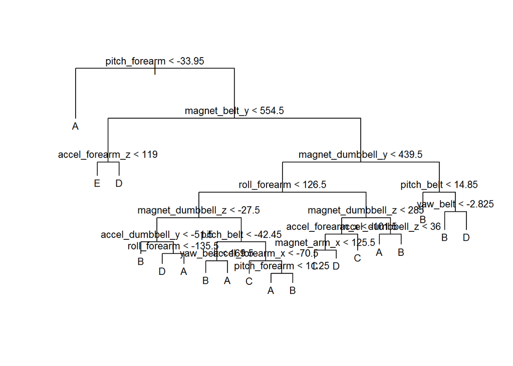

```r
plot(tree.training)
text(tree.training,pretty=0, cex =.8)
```

Cross Validation

We are going to check the performance of the tree on the testing data by cross validation.

```r
tree.pred=predict(tree.training,testing,type="class")
predMatrix = with(testing,table(tree.pred,classe))
sum(diag(predMatrix))/sum(as.vector(predMatrix))
```

```
## [1] 0.6603
```

This tree was grown to full depth, and might be too variable. We now use Cross Validation to prune it.

```r
cv.training=cv.tree(tree.training,FUN=prune.misclass)
cv.training
```

```
## $size
##  [1] 19 18 17 16 15 14 13 12 10  7  5  1
##
## $dev
##  [1] 4411 4493 4721 5171 5239 5288 5381 5756 6270 6762 7271 9831
##
## $k
##  [1]  -Inf  71.0 121.0 136.0 142.0 148.0 156.0 172.0 181.5 218.7 256.0
## [12] 641.8
##
## $method
## [1] "misclass"
##
## attr(,"class")
## [1] "prune"         "tree.sequence"
```

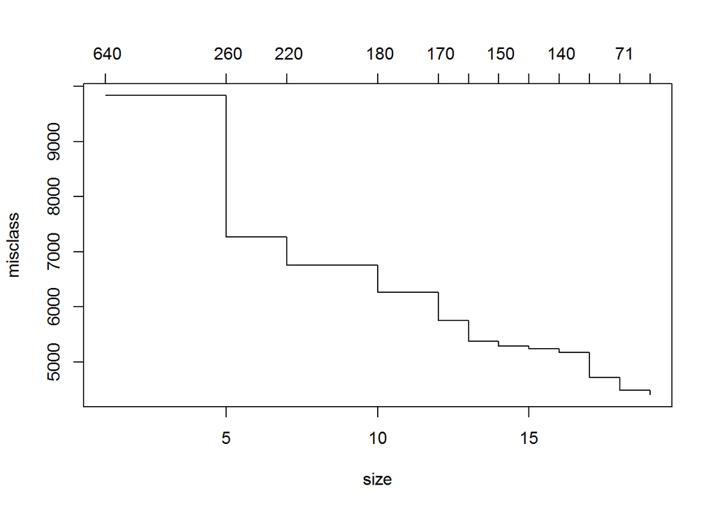

```r
plot(cv.training)
```

Suppose we prune it at size of nodes at 18.

```r
prune.training=prune.misclass(tree.training,best=18)
```

Now lets evaluate this pruned tree on the test data.

```r
tree.pred=predict(prune.training,testing,type="class")
predMatrix = with(testing,table(tree.pred,classe))
sum(diag(predMatrix))/sum(as.vector(predMatrix))
```

```
## [1] 0.6542
```

Random Forests

Random forests build lots of bushy trees, and then average them to reduce the variance.

```r
require(randomForest)
set.seed(12345)

rf.training=randomForest(classe~.,data=training,ntree=100, importance=TRUE)
rf.training
```

```
##
## Call:
##  randomForest(formula = classe ~ ., data = training, ntree = 100,      importance = TRUE)
##                Type of random forest: classification
##                      Number of trees: 100
## No. of variables tried at each split: 6
##
##         OOB estimate of  error rate: 0.6%
## Confusion matrix:
##      A    B    C    D    E class.error
## A 3902    3    0    0    1    0.001024
## B   13 2637    8    0    0    0.007901
## C    0   17 2378    1    0    0.007513
## D    1    0   26 2222    3    0.013321
## E    0    0    3    7 2515    0.003960
```

Our Random Forest model shows OOB estimate of error rate: 0.59% for the training data. Now we will predict it for out-of sample accuracy.

Now lets evaluate this tree on the test data.

```r
tree.pred=predict(rf.training,testing,type="class")
predMatrix = with(testing,table(tree.pred,classe))
sum(diag(predMatrix))/sum(as.vector(predMatrix))
```

```
## [1] 0.9946
```

0.99 means we got a very accurate estimate.

Now we can predict the testing data from the website.

```r
answers <- predict(rf.training, testingOrg)
answers
```

```
##  1  2  3  4  5  6  7  8  9 10 11 12 13 14 15 16 17 18 19 20
##  B  A  B  A  A  E  D  B  A  A  B  C  B  A  E  E  A  B  B  B
## Levels: A B C D E
```